## Exercises

In this assignment, you will practice determining if there is a linear relationship between two quantitative variables in various built-in datasets in R. You will calculate the correlation and create basic scatterplots using `ggplot2` to visualize the relationships. Each problem will involve different pairs of variables from different datasets. Provide solutions a nd explanations for each problem.

For each of the following problems, answer the following:

1. Calculate the correlation between the variables given.
2. Create a scatterplot using `ggplot2`.
3. Describe the scatterplot by discussing the form, direction, and strength of the relationship.
4. Determine if this could be a good candidate for linear regression.

### Problem 1: Iris Dataset - Sepal Length vs Petal Length

**Task:** Determine if there is a linear relationship between `Sepal.Length` and `Petal.Length` in the `iris` dataset.

**Solution and Explanation:**

```r
# Load ggplot2 and iris dataset
library(ggplot2)
data(iris)

# Calculate correlation
cor_sepal_petal <- cor(iris$Sepal.Length, iris$Petal.Length)
cor_sepal_petal
```

```
## [1] 0.8717538
```

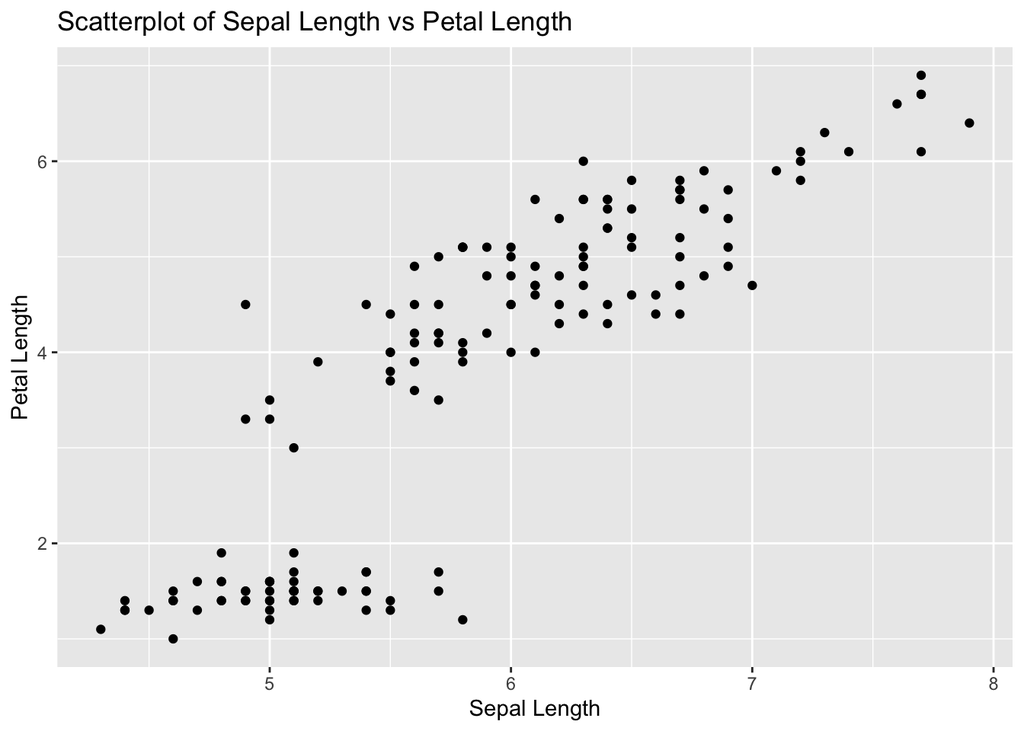

```r
# Create scatterplot
ggplot(iris, aes(x = Sepal.Length, y = Petal.Length)) +
  geom_point() +
  labs(title = "Scatterplot of Sepal Length vs Petal Length", x = "Sepal Length", y = "Petal Length")
```

```r
# Explanation:
# The correlation value indicates the strength and direction of the linear relationship between Sepal Length and Petal Length.
# The scatterplot visualizes this relationship.
```

### Problem 2: Airquality Dataset - Ozone vs Wind

**Task:** Determine if there is a linear relationship between `Ozone` and `Wind` in the `airquality` dataset.

**Solution and Explanation:**

```r
# Load ggplot2 and airquality dataset
library(ggplot2)
data(airquality)

# Remove NA values
airquality_clean <- na.omit(airquality)

# Calculate correlation
cor_ozone_wind <- cor(airquality_clean$Ozone, airquality_clean$Wind)
cor_ozone_wind
```

```
## [1] -0.6124966
```

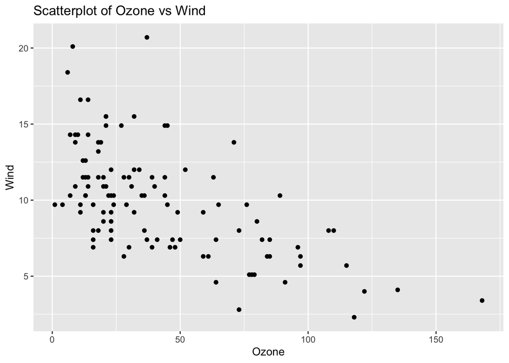

```r
# Create scatterplot
ggplot(airquality_clean, aes(x = Ozone, y = Wind)) +
  geom_point() +
  labs(title = "Scatterplot of Ozone vs Wind", x = "Ozone", y = "Wind")
```

```r
# Explanation:
# The correlation value indicates the strength and direction of the linear relationship between Ozone and Wind.
# The scatterplot visualizes this relationship.
```

### Problem 3: ToothGrowth Dataset - Dose vs Length

**Task:** Determine if there is a linear relationship between `dose` and `len` in the `ToothGrowth` dataset.

**Solution and Explanation:**

```r
# Load ggplot2 and ToothGrowth dataset
library(ggplot2)
data(ToothGrowth)

# Calculate correlation
cor_dose_len <- cor(ToothGrowth$dose, ToothGrowth$len)
cor_dose_len
```

```
## [1] 0.8026913
```

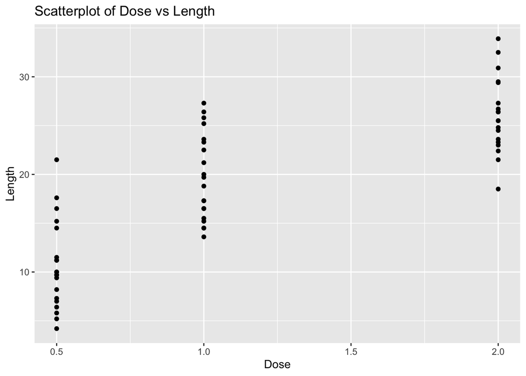

```r
# Create scatterplot
ggplot(ToothGrowth, aes(x = dose, y = len)) +
  geom_point() +
  labs(title = "Scatterplot of Dose vs Length", x = "Dose", y = "Length")
```

```r
# Explanation:
# The correlation value indicates the strength and direction of the linear relationship between Dose and Length.
# The scatterplot visualizes this relationship.
```

### Problem 4: Cars Dataset - Speed vs Stopping Distance

**Task:** Determine if there is a linear relationship between `speed` and `dist` in the `cars` dataset.

**Solution and Explanation:**

```r
# Load ggplot2 and cars dataset
library(ggplot2)
data(cars)

# Calculate correlation
cor_speed_dist <- cor(cars$speed, cars$dist)
cor_speed_dist
```

```
## [1] 0.8068949
```

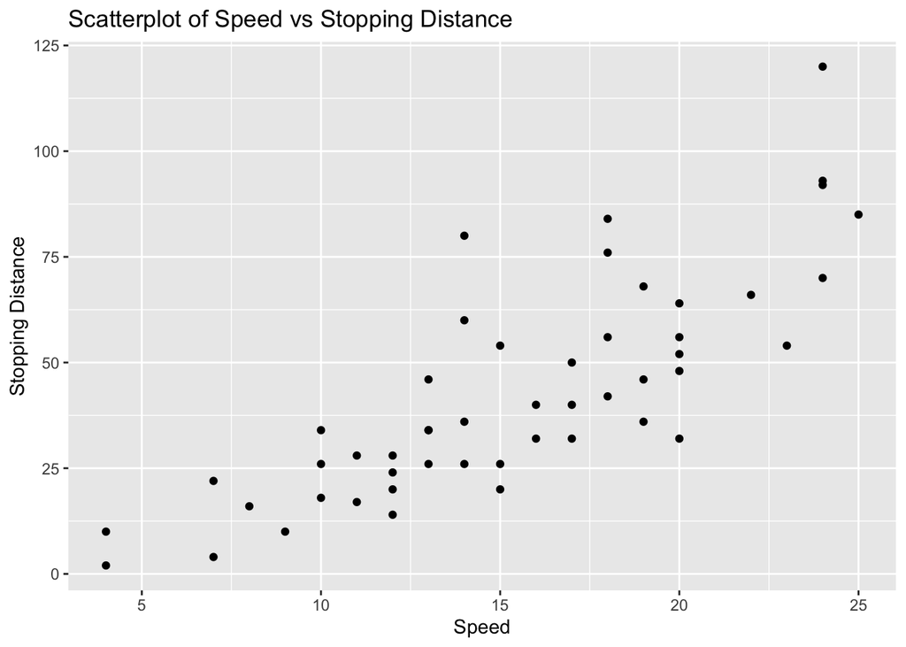

```r
# Create scatterplot
ggplot(cars, aes(x = speed, y = dist)) +
  geom_point() +
  labs(title = "Scatterplot of Speed vs Stopping Distance", x = "Speed", y = "Stopping Distance")
```

```r
# Explanation:
# The correlation value indicates the strength and direction of the linear relationship between Speed and Stopping Distance.
# The scatterplot visualizes this relationship.
```

### Problem 5: Faithful Dataset - Eruptions vs Waiting Time

**Task:** Determine if there is a linear relationship between `eruptions` and `waiting` in the `faithful` dataset.

**Solution and Explanation:**

```r
# Load ggplot2 and faithful dataset
library(ggplot2)
data(faithful)

# Calculate correlation
cor_eruptions_waiting <- cor(faithful$eruptions, faithful$waiting)
cor_eruptions_waiting
```

```
## [1] 0.9008112
```

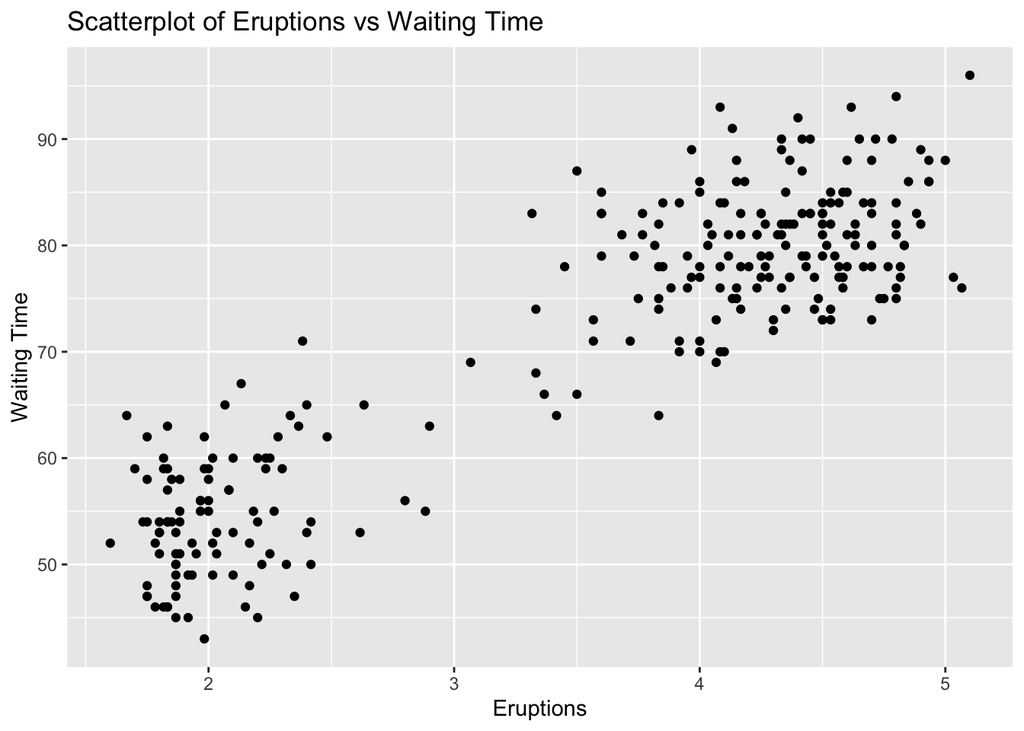

```r
# Create scatterplot
ggplot(faithful, aes(x = eruptions, y = waiting)) +
  geom_point() +
  labs(title = "Scatterplot of Eruptions vs Waiting Time", x = "Eruptions", y = "Waiting Time")
```

```r
# Explanation:
# The correlation value indicates the strength and direction of the linear relationship between Eruptions and Waiting Time.
# The scatterplot visualizes this relationship.
```

### Problem 6: ChickWeight Dataset - Time vs Weight

**Task:** Determine if there is a linear relationship between `Time` and `weight` in the `ChickWeight` dataset.

**Solution and Explanation:**

```r
# Load ggplot2 and ChickWeight dataset
library(ggplot2)
data(ChickWeight)

# Calculate correlation
cor_time_weight <- cor(ChickWeight$Time, ChickWeight$weight)
cor_time_weight
```

```
## [1] 0.8371017
```

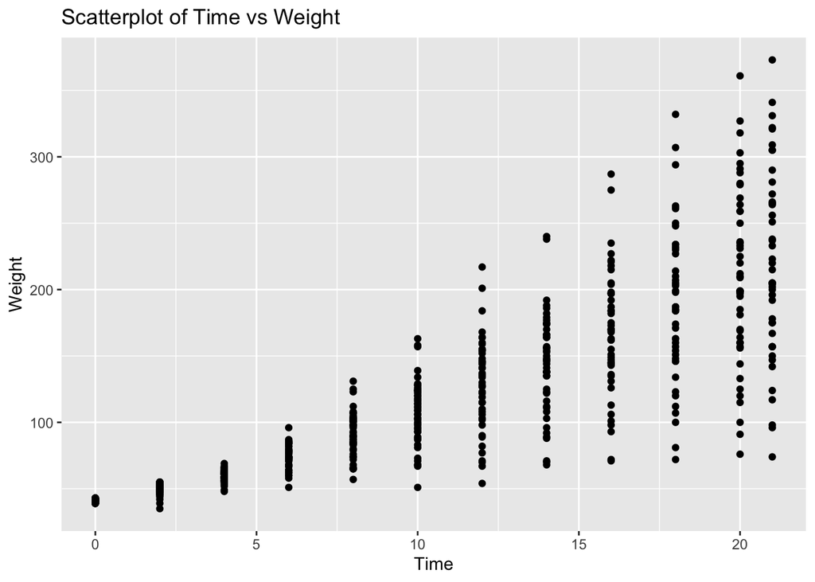

```r
# Create scatterplot
ggplot(ChickWeight, aes(x = Time, y = weight)) +
  geom_point() +
  labs(title = "Scatterplot of Time vs Weight", x = "Time", y = "Weight")
```

```r
# Explanation:
# The correlation value indicates the strength and direction of the linear relationship between Time and Weight.
# The scatterplot visualizes this relationship.
```

### Problem 7: Pressure Dataset - Temperature vs Pressure

**Task:** Determine if there is a linear relationship between `temperature` and `pressure` in the `pressure` dataset.

**Solution and Explanation:**

```r
# Load ggplot2 and pressure dataset
library(ggplot2)
data(pressure)

# Calculate correlation
cor_temperature_pressure <- cor(pressure$temperature, pressure$pressure)
cor_temperature_pressure
```

```
## [1] 0.7577923
```

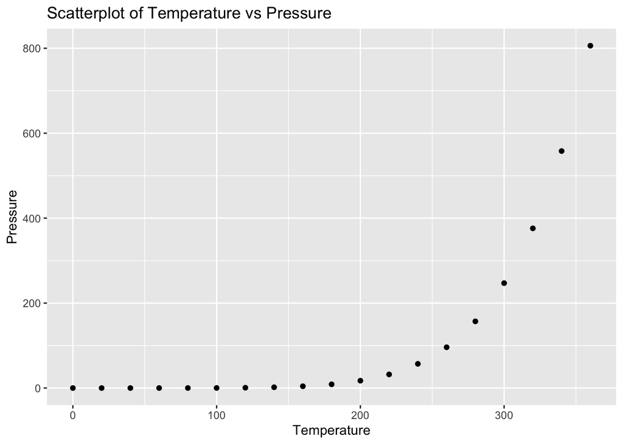

```r
# Create scatterplot
ggplot(pressure, aes(x = temperature, y = pressure)) +
  geom_point() +
  labs(title = "Scatterplot of Temperature vs Pressure", x = "Temperature", y = "Pressure")
```

```r
# Explanation:
# The correlation value indicates the strength and direction of the linear relationship between Temperature and Pressure.
# The scatterplot visualizes this relationship.
```

### Problem 8: Trees Dataset - Girth vs Volume

**Task:** Determine if there is a linear relationship between `Girth` and `Volume` in the `trees` dataset.

**Solution and Explanation:**

```r
# Load ggplot2 and trees dataset
library(ggplot2)
data(trees)

# Calculate correlation
cor_girth_volume <- cor(trees$Girth, trees$Volume)
cor_girth_volume
```

```
## [1] 0.9671194
```

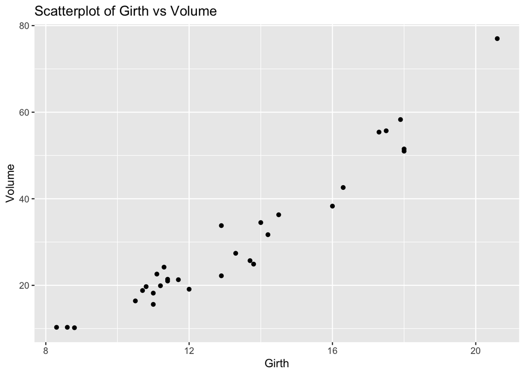

```r
# Create scatterplot
ggplot(trees, aes(x = Girth, y = Volume)) +
  geom_point() +
  labs(title = "Scatterplot of Girth vs Volume", x = "Girth", y = "Volume")
```

```r
# Explanation:
# The correlation value indicates the strength and direction of the linear relationship between Girth and Volume.
# The scatterplot visualizes this relationship.
```

### Problem 9: USArrests Dataset - Urban Population vs Assaults

**Task:** Determine if there is a linear relationship between `UrbanPop` and `Assault` in the `USArrests` dataset.

**Solution and Explanation:**

```r
# Load ggplot2 and USArrests dataset
library(ggplot2)
data(USArrests)

# Calculate correlation
cor_urbanpop_assault <- cor(USArrests$UrbanPop, USArrests$Assault)
cor_urbanpop_assault
```

```
## [1] 0.2588717
```

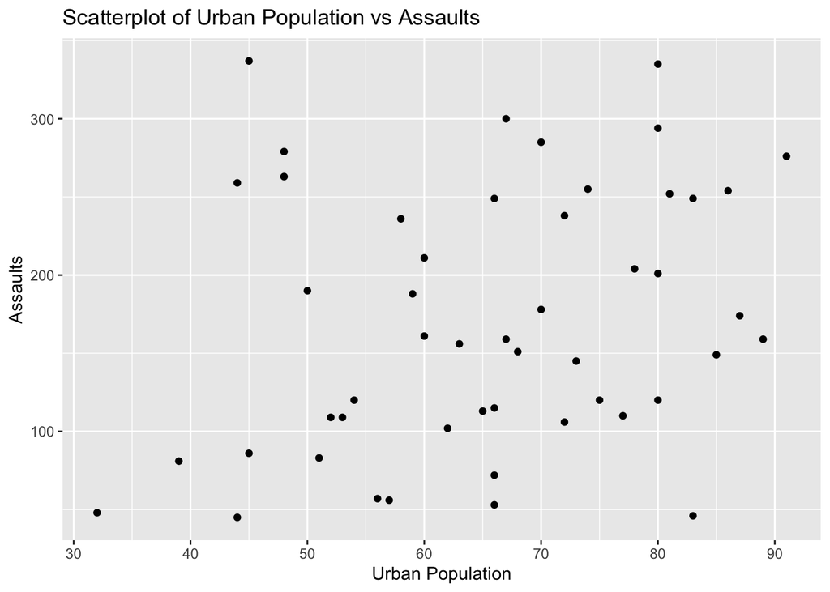

```r
# Create scatterplot
ggplot(USArrests, aes(x = UrbanPop, y = Assault)) +
  geom_point() +
  labs(title = "Scatterplot of Urban Population vs Assaults", x = "Urban Population", y = "Assaults")
```

```r
# Explanation:
# The correlation value indicates the strength and direction of the linear relationship between Urban Population and Assaults.
# The scatterplot visualizes this relationship.
```

### Problem 10: Swiss Dataset - Education vs Fertility

**Task:** Determine if there is a linear relationship between `Education` and `Fertility` in the `swiss` dataset.

**Solution and Explanation:**

```r
# Load ggplot2 and swiss dataset
library(ggplot2)
data(swiss)

# Calculate correlation
cor_education_fertility <- cor(swiss$Education, swiss$Fertility)
cor_education_fertility
```

```
## [1] -0.6637889
```

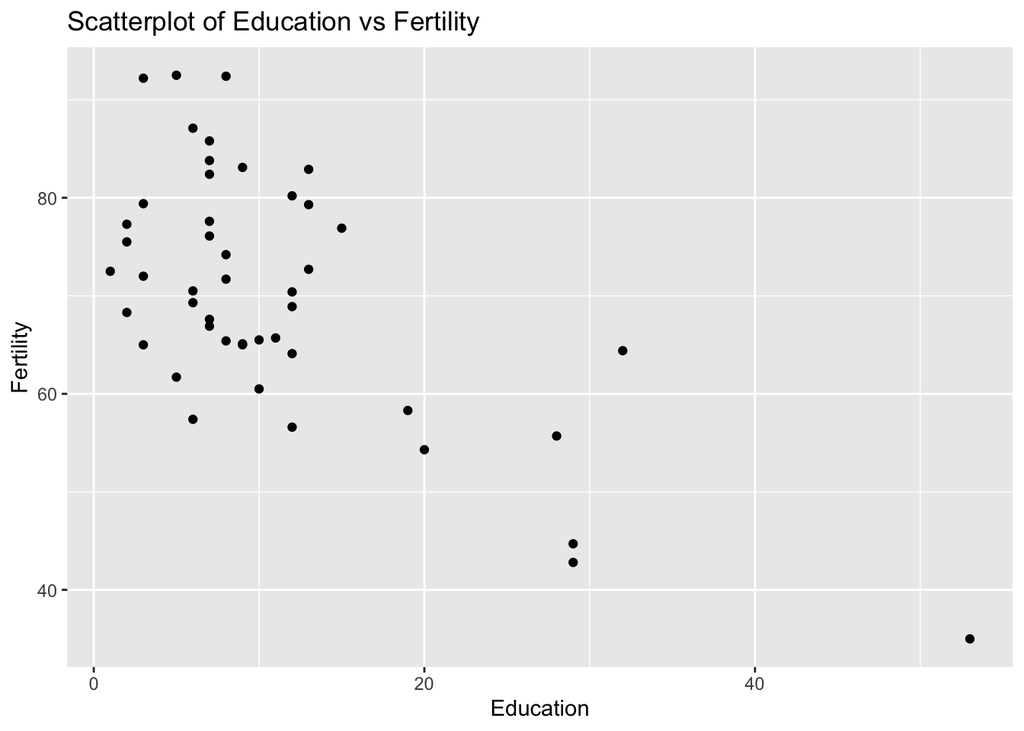

```r
# Create scatterplot
ggplot(swiss, aes(x = Education, y = Fertility)) +
  geom_point() +
  labs(title = "Scatterplot of Education vs Fertility", x = "Education", y = "Fertility")
```

```r
# Explanation:
# The correlation value indicates the strength and direction of the linear relationship between Education and Fertility.
# The scatterplot visualizes this relationship.
```